# TempStats_Using_Chemical_Data_Times

## Introduction (WIP)

This notebook uses the custom function TempStats, in the custom library PescStats (available on GitHub at sbeaulieu/Pescadero/PescStats), to get a plot (barplot or scatterplot) and summary statistics of temperature data from a 10 minute interval near the end of chemical measurements. TempStats() relies on functions from the package lubridate. The library devtools is also called, but is only necessary for installing PescStats from GitHub. The functions in PescStats are frequently updated, so PescStats may need to be reinstalled on occasion. Variations on the functions sum_stats() and TempStats() are defined below as sum_stats_values() and TempStats_Times(), as well as the two novel functions chem_measure() and ISS_Stats(). temp_start(), temp_duration(), and ISS_period() have also been added; they were originally part of previous functions (chem_measure() for the first two, ISS_Stats() for the last one), but were separated out to avoid globally defining variables with functions. The purposes of all additional functions are commented where they are defined.

This notebook also uses eight specific .csv files: one giving, among other things, the start and end times of chemical measurements per location, and one file for each of the seven stations. The majority of the functions utilized in this notebook, but especially chem_measure(), TempStats(), and TempStats_times() are built around the syntax utilized in the files they call, referencing things such as specific column headers. These files, as well as the current version of this R Notebook, may be found in the Google Drive folder “Files for R Temperature Notebook (includes temp logs)”. For ease of modification, the file names are assigned to variables in the r chunk {r variables called often}, under the subheading “Assigning file names to variables”. This way, if the file is renamed, the name just be modified in this chunk, rather than having to modify every instance in which that file is called.

This notebook currently outputs all results within each chunk, not to separate files. Each temperature graph for a given location (eg, bullseye or away) should be generated at the end of the code for that location, along with the printed summary statistics. The table detailing temperature and chemical times per location, along with the summary statistics, is at the very end of this notebook.

### R Libraries:

```r
#install.packages("lubridate")  #install lubridate, if not already present on the machine
library(lubridate)#load Lubridate
#library(devtools) #load devtools (only necessary if installing PescStats from GitHub)
#install_github("sbeaulieu/Pescadero/PescStats") #installs PescStats; not a bad idea to frequently re-install due to ongoing modifications of the package
library(PescStats) #load PescStats
#install.packages(ggplot2)
library(ggplot2)
library(knitr)
```

### Locally defined functions:

```r
sum_stats_values<-function(x){   #variation of sum_stats() function in PescStats to return JUST the summary statistic values indicated below; original sum_stats() function prints these values with labels in the R console
  decimal<-strsplit(as.character(x),"\\.")[[1]][2]
  if(is.na(decimal))
    digits <- 1 #sets up for rounding to 1 decimal place if original data is whole numbers
  else
    digits<-nchar(decimal)+1 #sets up for rounding to 1 more decimal place than in original data
  min<-round(min(x, na.rm=T), digits=digits)
  max<-round(max(x, na.rm=T), digits=digits)
  med<-round(median(x, na.rm=T), digits=digits) #calculates median of data, with NAs removed and rounding
  mean<-round(mean(x, na.rm=T), digits=digits) #calculates mean of data, with NAs removed and rounding
  range<-round(max(x, na.rm=T)-min(x, na.rm=T), digits=digits) #calculates range of data, with NAs removed and rounding
  var<-round(var(x, na.rm=T), digits=digits) #calculates variance of data, with NAs removed and rounding
  sd<-round(sd(x, na.rm=T), digits=digits) #calculates standard devation of data, with NAs removed and rounding
  SEM<-round(SEM(x),digits=digits) #calculates standard error of the mean of data, with NAs removed and roundign
  ISS_summary<-c(max,min,med,mean,range,var,sd,SEM) #stores summary statistics
}

chem_measure<-function(x,y,z){ #catered to pulling chem data times from various versions of the same spreadsheet
  all_ISS<-read.csv(x) #x is file name of this iteration of the sheet
  this_ISS<-subset(all_ISS, all_ISS$Station==y) #y is station number (00#); subsets just the measurements from that station
  this_locale<-subset(this_ISS,this_ISS$location==z) #z is location (bullseye, away, excavated_bullseye); subsets
  start2<-as.character(this_locale$Chem_Data_Start_Text) #if not stored as character, when concatinating summary stats, temperature times, and chemical times together later, the chemical times are either appended or prefixed to every other variable rather than standing alone
  end2<-as.character(this_locale$Chem_Data_End_Text)
    chem_time<-c(start2,end2)
}

#making temp_start and duration separate functions to avoid using <<- or assign()
temp_start<-function(x,y,z){ #same input as chem_measure()
  all_ISS<-read.csv(x) #these lines, through defining chem_end, are identical to chem_measure()
  this_ISS<-subset(all_ISS, all_ISS$Station==y)
  this_locale<-subset(this_ISS,this_ISS$location==z)
 # chem_start<-ymd_hms(this_locale$Chem_Data_Start_Text) #previously in chem_measure; chemical data start time as chem_start, and in a format usable by lubridate()
  chem_end<-ymd_hms(this_locale$Chem_Data_End_Text) #previously in chem_measure
#   interval<-interval(chem_start,chem_end) #sets interval for calculating length of time btwn start and end
#   length<-time_length(interval,unit="minutes") #calculates time difference, in min, btwn start end end
# #  if (length<10) initially used 10 min but then Scott told us about several minute lag for mass spec
#   if (length<15)
#     start<-chem_start #sets temp_start to start time of chemistry measurements if chemistry taken for less than 15min
#   else
# #    start<-ymd_hms(chem_end)-minutes(10) #sets temp_start to 10min before the end of chemical measurements if chemistry taken for 10 minutes or more
    start<-ymd_hms(chem_end)-minutes(15) #sets temp_start to 15min before the end of chemical measurements
} #remove if statement, start time always 15 minutes before chem_end

test_chem_duration<-function(x,y,z){ #same input as chem_measure()
  all_ISS<-read.csv(x) #these lines, through defining chem_end, are identical to chem_measure()
  this_ISS<-subset(all_ISS, all_ISS$Station==y)
  this_locale<-subset(this_ISS,this_ISS$location==z)
  chem_start<-ymd_hms(this_locale$Chem_Data_Start_Text)
  chem_end<-ymd_hms(this_locale$Chem_Data_End_Text)
  interval<-interval(chem_start,chem_end)
  length<-time_length(interval,unit="minutes")
if (length<15)
   print("chemistry measurement less than 15 minutes, temperature analysis may be outside of chemistry measurement - watch video")
 else
   print("chemistry measurement equal to greater than 15 minutes, temperatures analyzed are within chemistry measurement")
}

#setting all temp times to 10 minutes, making this function unncessary
# temp_duration<-function(x,y,z){ #same input as chem_measure() and temp_duration()
#   all_ISS<-read.csv(x) #through defining chem_end, identical to chem_measure() and temp_start(); originally these 3 were one function, but were separated to avoid defining variables globally within the function
#   this_ISS<-subset(all_ISS, all_ISS$Station==y)
#   this_locale<-subset(this_ISS,this_ISS$location==z)
#   chem_start<-ymd_hms(this_locale$Chem_Data_Start_Text)
#   chem_end<-ymd_hms(this_locale$Chem_Data_End_Text)
#   interval<-interval(chem_start,chem_end)
#   length<-time_length(interval,unit="minutes")
#     if (length<10)
#       duration<-length #sets duration to entirety of chemical measurement if chemistry taken for less than 10 minutes
#     else
#       duration<-10 #sets duration to 10 minutes if more than 10 minutes of chemistry taken
# }


TempStats_times<-function(x,t,d){  #variation of TempStats() function in PescStats that outputs just the times that TempStats() uses
  ISS<-read.csv(x) #x is actual temperature log
  ISS$time<-ymd_hms(ISS$time) #assumes timestamps in "time" column are in year month day hour minute second format; from lubridate package
  start<-ymd_hms(t) #t is the desired start time for temperature
  end<-ymd_hms(start)+minutes(d) #d is the durration of the measurement
  ISS_period<-subset(ISS, time>start & time<end) #assigns ISS_period globally so it can be used outside of the function
   start2<-paste(start) #have to paste start and end because otherwise, the data will be converted to the timezone of the machine when printed, or it will print a string of numbers that is, presumably, a representation of the time value rather than the actual value; something to do with lubridate maybe
  end2<-paste(end)
  t_timeframe<-c(start2,end2) #stores start and end time of temperature data analyzed)
}

#creating a separate function to avoid using <<- or assign()
ISS_period<-function(x,t,d){ #same input as TempStats_times(), creates subset of temperature data for the appropriate times
    ISS<-read.csv(x) #same as part of TempStats_times(), separated to avoid globally defining ISS_period w/in it
  ISS$time<-ymd_hms(ISS$time)
  start<-ymd_hms(t)
  end<-ymd_hms(start)+minutes(d)
  ISS_period<-subset(ISS, time>start & time<end)
}

ISS_Stats<-function(c,t,s){ #x is variable for whole ISS, c is variable for chemistry times, t is variable for temp times, s is for sum_stats
  x<-paste(t) #pastes temperature times because lubridate(?) is still doing *something* funky with times
  y<-paste(c)
  x<-c(y,x,s) #creates vector of data for a given site, in this order: chemical data start, chemical data end, temp data start, temp data end, mean, median, range, variance, st. dev, SEM
}
```

### Assigning file names to variables

```r
chemical_times_csv<-"Pescadero_Chemical_Timestamps_31May2018_modified.csv"
    #column headers have been renamed from initial file sent by Scott to remove spaces
    #additional columns have been added to put chemical times in format recognized by lubridate
    #rows wh ere chemical start/end times have been manually removed from this spreadsheet; they caused issues with chem_measure

#temp_start is created for each location by chem_measure() based on the starting chemical time in chemical_times_csv
#duration is created for each location by chem_measure() based on the length of chemical measurements in chemical_times_csv, default is 10min
ISS001<-"temp_log_001.csv"
ISS002<-"temp_log_002.csv"
ISS003<-"temp_log_003.csv"
ISS004<-"temp_log_004.csv"
ISS005<-"temp_log_005.csv"
ISS006<-"temp_log_006.csv"
ISS007<-"temp_log_007.csv"

duration<-10 #set all durations to 10 minutes
```

## Temperature Analyses

ISS 001

```r
#Bullseye
  chem_time<-chem_measure(chemical_times_csv,1,"bullseye") #print chem start and end times; chemical_times_csv defined in {r variables called often}
    start<-temp_start(chemical_times_csv,1,"bullseye") #isolate chemical start time, save as variable "start"
          start<-start-minutes(2) #need to start temp 2 minutes earlier, as discerned from graph of unmodified "start" and from video
  t_timeframe<-TempStats_times(ISS001,start,duration) #get temp start and end times
    ISS_duration<-ISS_period(ISS001,start,duration) #subsets station data into table for just this time period
  ISS_summary<-sum_stats_values(ISS_duration$temperature) #get summary statistics
ISS1_bullseye<-ISS_Stats(chem_time,t_timeframe,ISS_summary) #creates vector of the times and summary statistics for ISS1 Bullseye

site<-"ISS 001"
location<-"bullseye"
ISS1bull_duration<-cbind(ISS_duration,site,location) #columns of site and location, for cumulative boxplot

print(c(site,location))
```

```
## [1] "ISS 001"  "bullseye"
```

```r
test_chem_duration(chemical_times_csv,1,"bullseye") #isolate chemical duration, save as variable "duration"
```

```
## [1] "chemistry measurement equal to greater than 15 minutes, temperatures analyzed are within chemistry measurement"
```

```
## Temperature Data from 2017-10-31 15:06:00 to 2017-10-31 15:16:00
## Summary Statistics:
## maximum = 33.99
## minimum = 16.88
## median = 29.955
## mean = 28.32
## range = 17.11
## variance = 24.121
## standard deviation = 4.911
## Standard Error of the Mean = 0.248
```

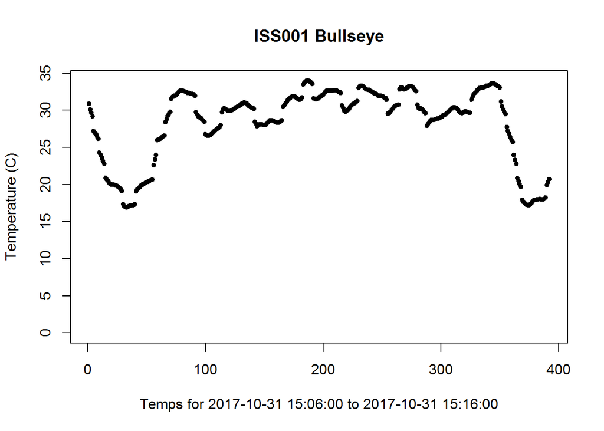

```r
TempStats(ISS001,start,duration,"ISS001 Bullseye", "scatterplot") #calculates summary statistics, temperature timeframe given temperature start time and duration (determined by chem_measure() or input manually), and produces plot (bar or scatter) of temperature
```

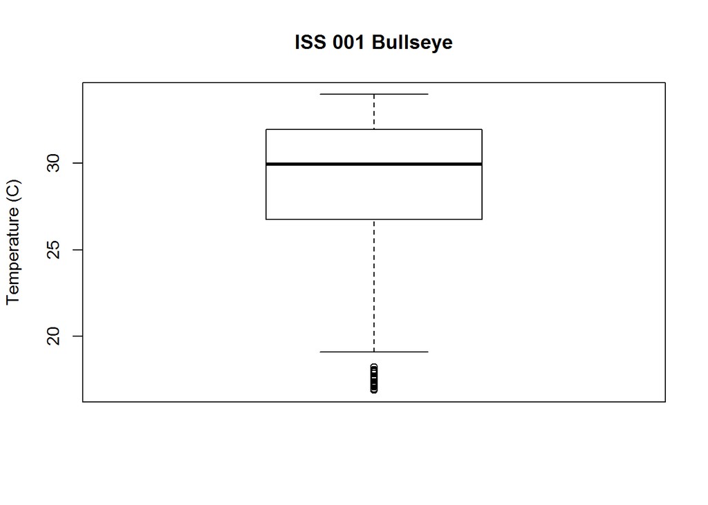

```r
boxplot(temperature~location,data=ISS1bull_duration, main="ISS 001 Bullseye", ylab="Temperature (C)") #boxplot of just ISS1 bullseye
```

```r
#50cm Away
  chem_time<-chem_measure(chemical_times_csv, 1,"away")
 #   start<-temp_start(chemical_times_csv,1,"away")
start<-"2017-10-31 16:10:00" #manually determined time wand near away
duration2<-7 #moved wand before 10 minutes
  t_timeframe<-TempStats_times(ISS001,start,duration2)
    ISS_duration<-ISS_period(ISS001,start,duration2)
  ISS_summary<-sum_stats_values(ISS_duration$temperature)
ISS1_away<-ISS_Stats(chem_time,t_timeframe,ISS_summary)

site<-"ISS 001"
location<-"away"
ISS1away_duration<-cbind(ISS_duration,site,location)

print(c(site,location))
```

```
## [1] "ISS 001" "away"
```

```r
test_chem_duration(chemical_times_csv,1,"away")
```

```
## [1] "chemistry measurement less than 15 minutes, temperature analysis may be outside of chemistry measurement - watch video"
```

```
## Temperature Data from 2017-10-31 16:10:00 to 2017-10-31 16:17:00
## Summary Statistics:
## maximum = 1.97
## minimum = 1.95
## median = 1.96
## mean = 1.962
## range = 0.02
## variance = 0
## standard deviation = 0.005
## Standard Error of the Mean = 0
```

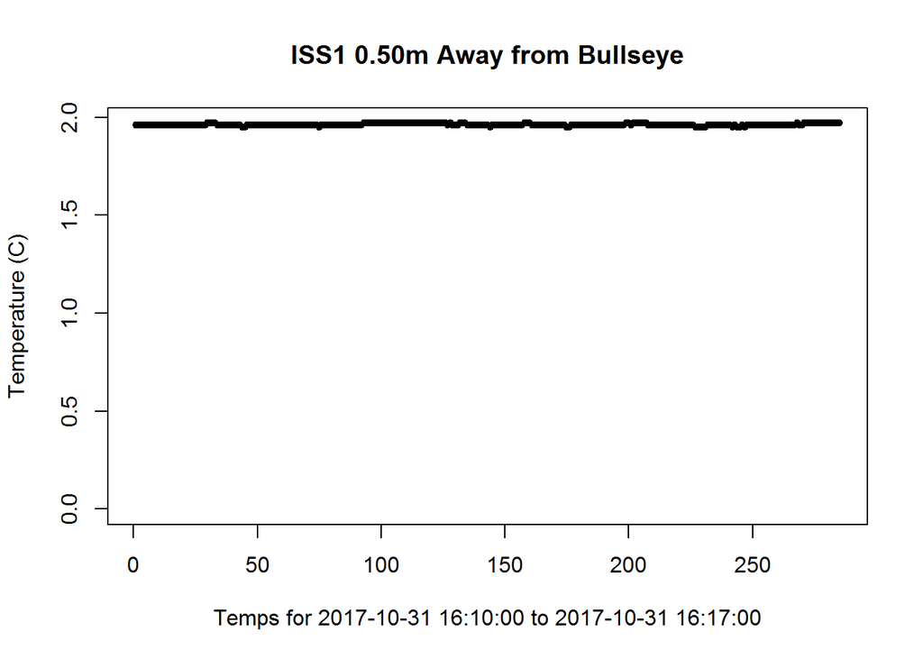

```r
TempStats(ISS001,start,duration2,"ISS1 0.50m Away from Bullseye","scatterplot")
```

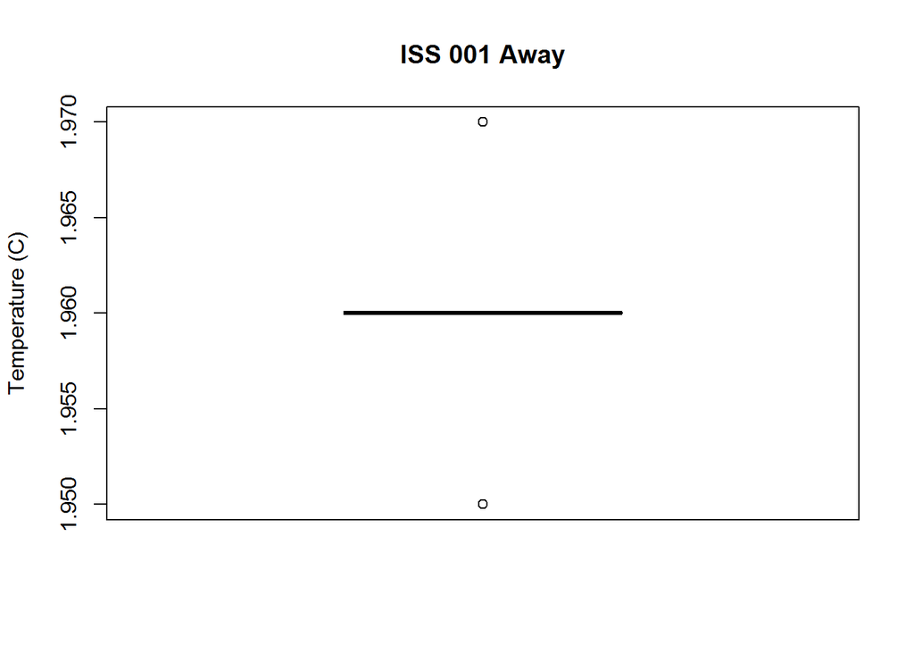

```r
away1box<-boxplot(temperature~location,data=ISS1away_duration, main="ISS 001 Away", ylab="Temperature (C)")
```

ISS 002

```r
#Bullseye
  chem_time<-chem_measure(chemical_times_csv,2,"bullseye")
    start<-temp_start(chemical_times_csv,2,"bullseye")
  t_timeframe<-TempStats_times(ISS002,start,duration)
    ISS_duration<-ISS_period(ISS002,start,duration)
  ISS_summary<-sum_stats_values(ISS_duration$temperature)
ISS2_bullseye<-ISS_Stats(chem_time,t_timeframe,ISS_summary)

site<-"ISS 002"
location<-"bullseye"
ISS2bull_duration<-cbind(ISS_duration,site,location)

print(c(site,location))
```

```
## [1] "ISS 002"  "bullseye"
```

```r
test_chem_duration(chemical_times_csv,2,"bullseye")
```

```
## [1] "chemistry measurement less than 15 minutes, temperature analysis may be outside of chemistry measurement - watch video"
```

```
## Temperature Data from 2017-10-31 21:13:00 to 2017-10-31 21:23:00
## Summary Statistics:
## maximum = 21.3
## minimum = 12.42
## median = 17.87
## mean = 17.441
## range = 8.88
## variance = 5.243
## standard deviation = 2.29
## Standard Error of the Mean = 0.116
```

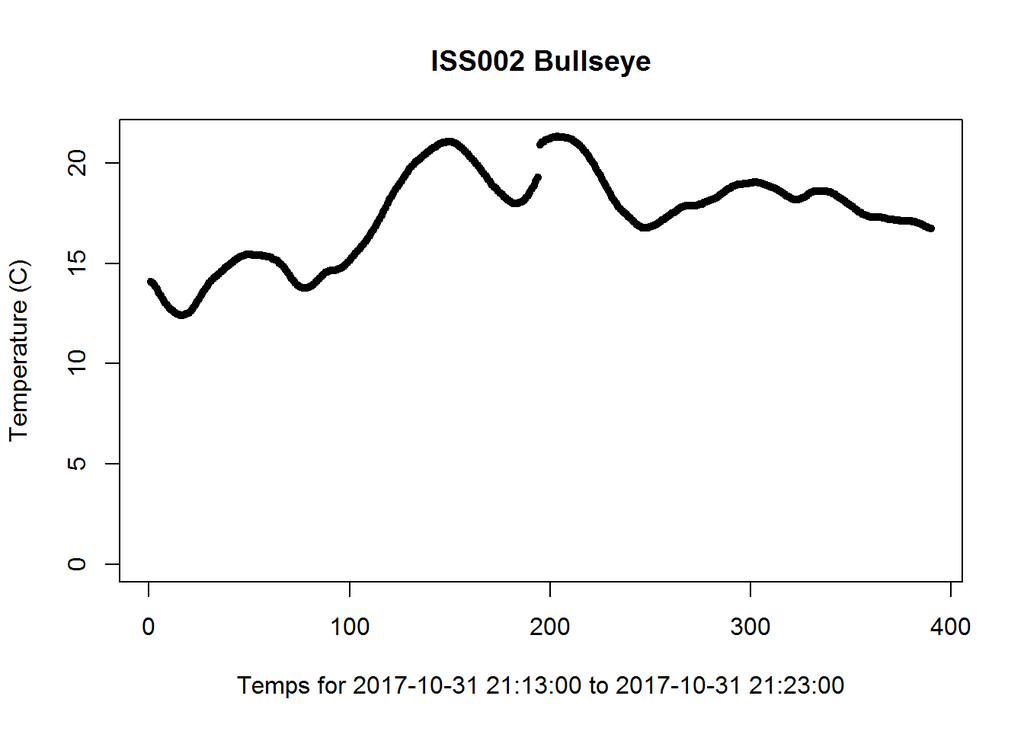

```r
TempStats(ISS002,start,duration,"ISS002 Bullseye", "scatterplot")
```

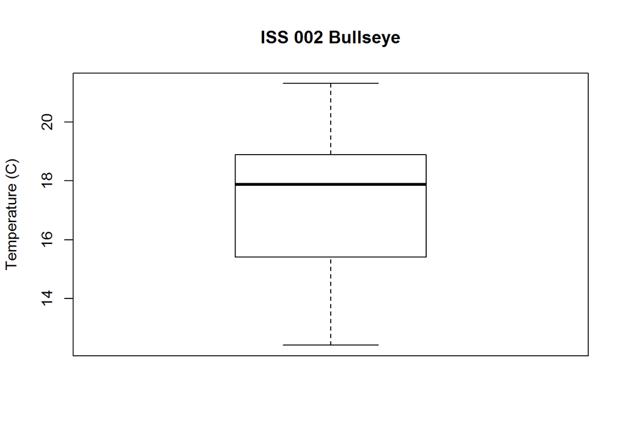

```r
boxplot(temperature~location,data=ISS2bull_duration, main="ISS 002 Bullseye", ylab="Temperature (C)")
```

```r
#50cm Away
  chem_time<-chem_measure(chemical_times_csv, 2,"away")
  #  start<-temp_start(chemical_times_csv,2,"away")
   start<-"2017-10-31 21:40:00" #manual start time based on video
  t_timeframe<-TempStats_times(ISS002,start,duration)
    ISS_duration<-ISS_period(ISS002,start,duration)
  ISS_summary<-sum_stats_values(ISS_duration$temperature)
ISS2_away<-ISS_Stats(chem_time,t_timeframe,ISS_summary)

site<-"ISS 002"
location<-"away"
ISS2away_duration<-cbind(ISS_duration,site,location)

print(c(site,location))
```

```
## [1] "ISS 002" "away"
```

```r
test_chem_duration(chemical_times_csv,2,"away")
```

```
## [1] "chemistry measurement less than 15 minutes, temperature analysis may be outside of chemistry measurement - watch video"
```

```
## Temperature Data from 2017-10-31 21:40:00 to 2017-10-31 21:50:00
## Summary Statistics:
## maximum = 3.14
## minimum = 2.21
## median = 2.63
## mean = 2.65
## range = 0.93
## variance = 0.051
## standard deviation = 0.227
## Standard Error of the Mean = 0.011
```

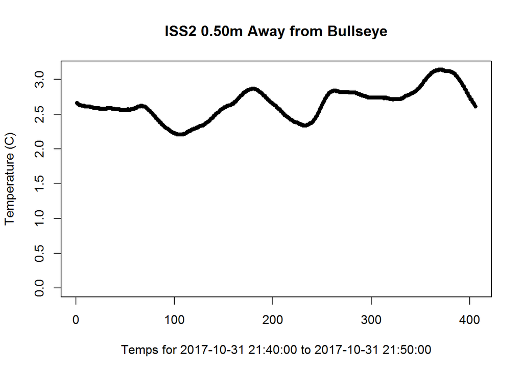

```r
TempStats(ISS002,start,duration,"ISS2 0.50m Away from Bullseye","scatterplot")
```

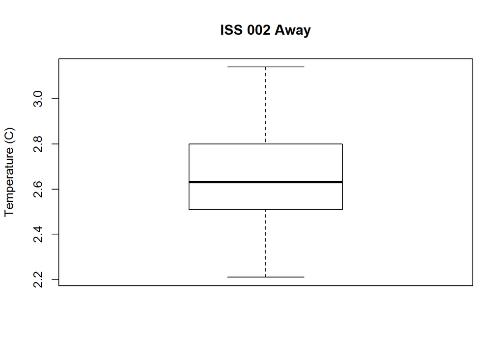

```r
boxplot(temperature~location,data=ISS2away_duration, main="ISS 002 Away", ylab="Temperature (C)")
```

ISS 003

```r
#Bullseye
  chem_time<-chem_measure(chemical_times_csv,3,"bullseye")
    start<-temp_start(chemical_times_csv,3,"bullseye")
  t_timeframe<-TempStats_times(ISS003,start,duration)
    ISS_duration<-ISS_period(ISS003,start,duration)
  ISS_summary<-sum_stats_values(ISS_duration$temperature)
ISS3_bullseye<-ISS_Stats(chem_time,t_timeframe,ISS_summary)

site<-"ISS 003"
location<-"bullseye"
ISS3bull_duration<-cbind(ISS_duration,site,location)

print(c(site,location))
```

```
## [1] "ISS 003"  "bullseye"
```

```r
test_chem_duration(chemical_times_csv,3,"bullseye")
```

```
## [1] "chemistry measurement equal to greater than 15 minutes, temperatures analyzed are within chemistry measurement"
```

```
## Temperature Data from 2017-11-01 22:23:00 to 2017-11-01 22:33:00
## Summary Statistics:
## maximum = 13.7
## minimum = 5.04
## median = 9.82
## mean = 9.376
## range = 8.66
## variance = 5.336
## standard deviation = 2.31
## Standard Error of the Mean = 0.115
```

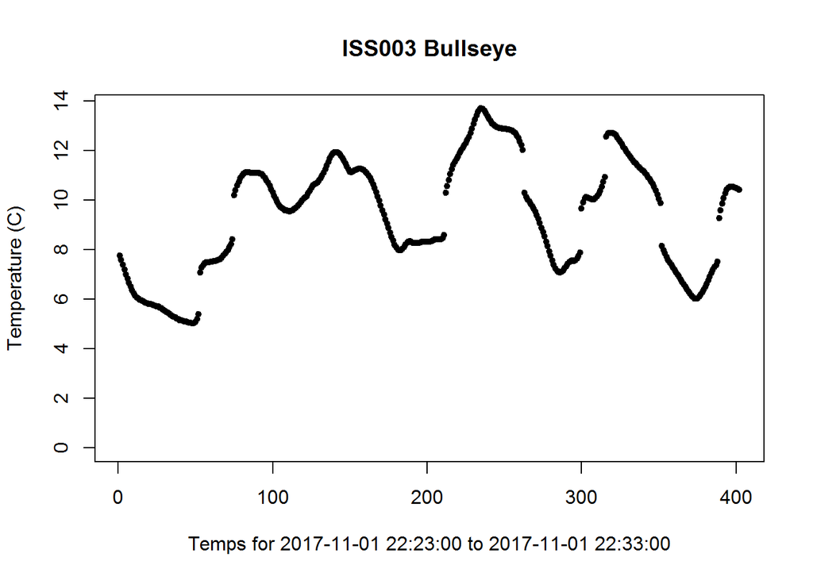

```r
TempStats(ISS003,start,duration,"ISS003 Bullseye", "scatterplot")
```

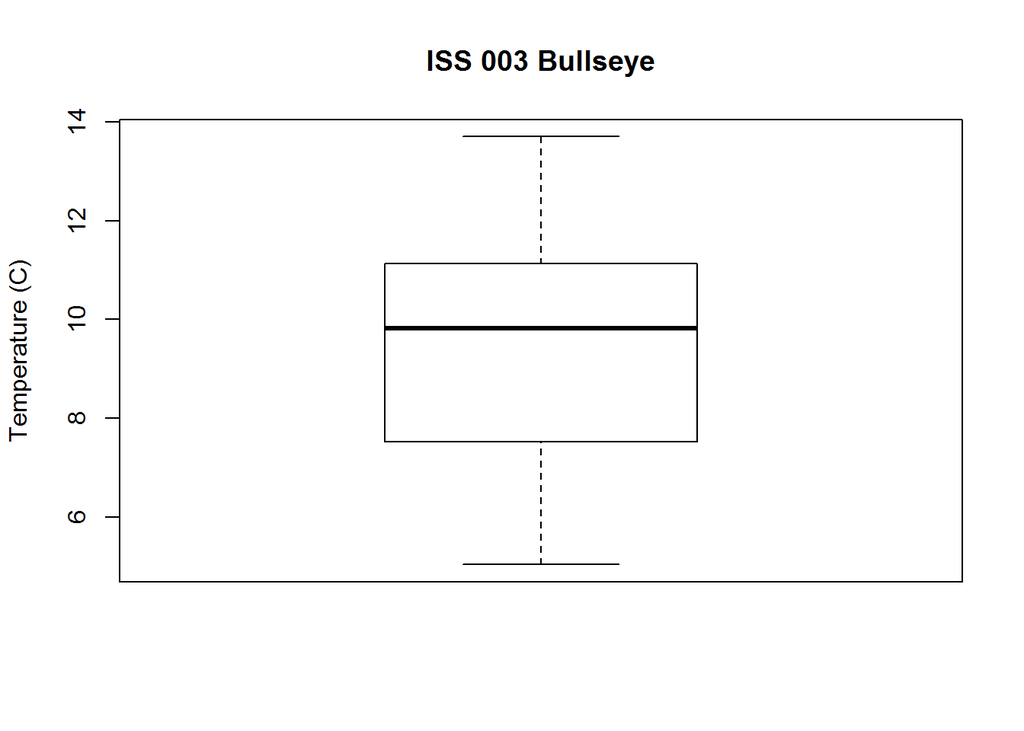

```r
boxplot(temperature~location,data=ISS3bull_duration, main="ISS 003 Bullseye", ylab="Temperature (C)")
```

```r
#50cm Away
  chem_time<-chem_measure(chemical_times_csv, 3,"away")
    #  start<-temp_start(chemical_times_csv,3,"away")
    start<-"2017-11-01 22:41:00" #earliest start temp record based on video
    duration2<-6 #in line with chemistry end
  t_timeframe<-TempStats_times(ISS003,start,duration2)
    ISS_duration<-ISS_period(ISS003,start,duration2)
  ISS_summary<-sum_stats_values(ISS_duration$temperature)
ISS3_away<-ISS_Stats(chem_time,t_timeframe,ISS_summary)

site<-"ISS 003"
location<-"away"
ISS3away_duration<-cbind(ISS_duration,site,location)

print(c(site,location))
```

```
## [1] "ISS 003" "away"
```

```r
print("Temp does not occur 15 minutes before chemistry end, and is a six minute duration to avoid taking temperature after ending chemistry collection.")
```

```
## [1] "Temp does not occur 15 minutes before chemistry end, and is a six minute duration to avoid taking temperature after ending chemistry collection."
```

```
## Temperature Data from 2017-11-01 22:41:00 to 2017-11-01 22:47:00
## Summary Statistics:
## maximum = 2.44
## minimum = 2.2
## median = 2.32
## mean = 2.32
## range = 0.24
## variance = 0
## standard deviation = 0.05
## Standard Error of the Mean = 0
```

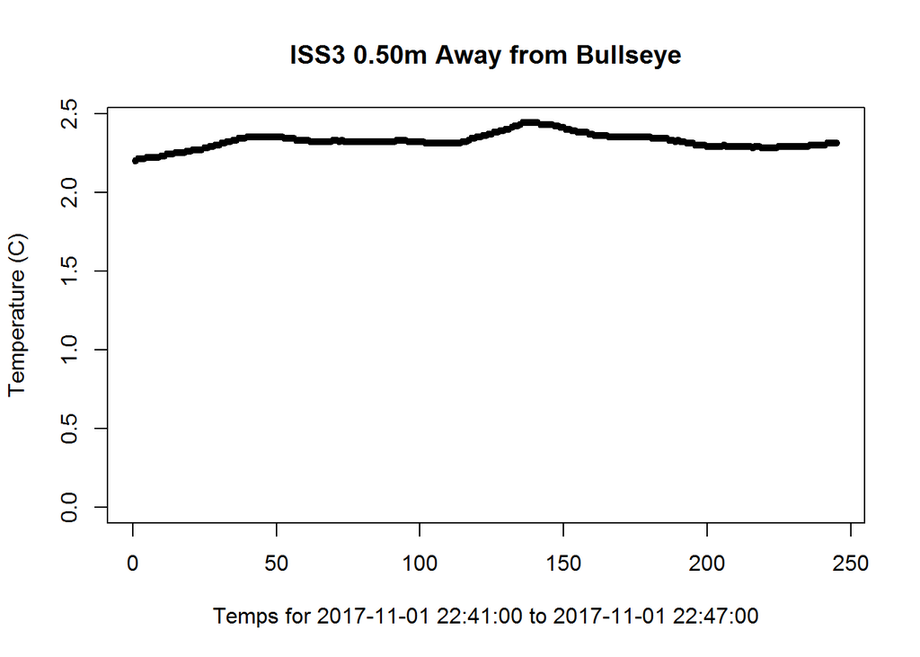

```r
TempStats(ISS003,start,duration2,"ISS3 0.50m Away from Bullseye","scatterplot")
```

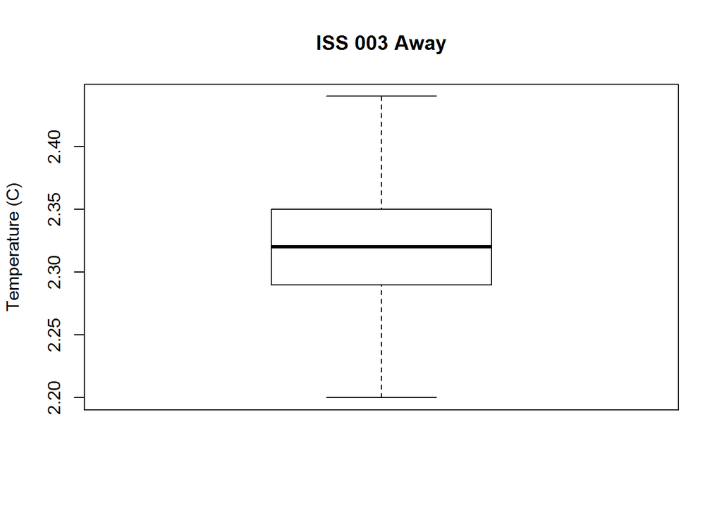

```r
boxplot(temperature~location,data=ISS3away_duration, main="ISS 003 Away", ylab="Temperature (C)")
```

ISS 004

```r
#Bullseye
  chem_time<-chem_measure(chemical_times_csv,4,"bullseye")
    start<-temp_start(chemical_times_csv,4,"bullseye")
#    start<-"2017-11-02 02:08:00" #manually determined start time, using video
    t_timeframe<-TempStats_times(ISS004,start,duration)
    ISS_duration<-ISS_period(ISS004,start,duration)
  ISS_summary<-sum_stats_values(ISS_duration$temperature)
ISS4_bullseye<-ISS_Stats(chem_time,t_timeframe,ISS_summary)

site<-"ISS 004"
location<-"bullseye"
ISS4bull_duration<-cbind(ISS_duration,site,location)

print(c(site,location))
```

```
## [1] "ISS 004"  "bullseye"
```

```r
test_chem_duration(chemical_times_csv,4,"bullseye")
```

```
## [1] "chemistry measurement equal to greater than 15 minutes, temperatures analyzed are within chemistry measurement"
```

```
## Temperature Data from 2017-11-02 02:14:00 to 2017-11-02 02:24:00
## Summary Statistics:
## maximum = 114.44
## minimum = 90.34
## median = 101.845
## mean = 101.796
## range = 24.1
## variance = 34.932
## standard deviation = 5.91
## Standard Error of the Mean = 0.299
```

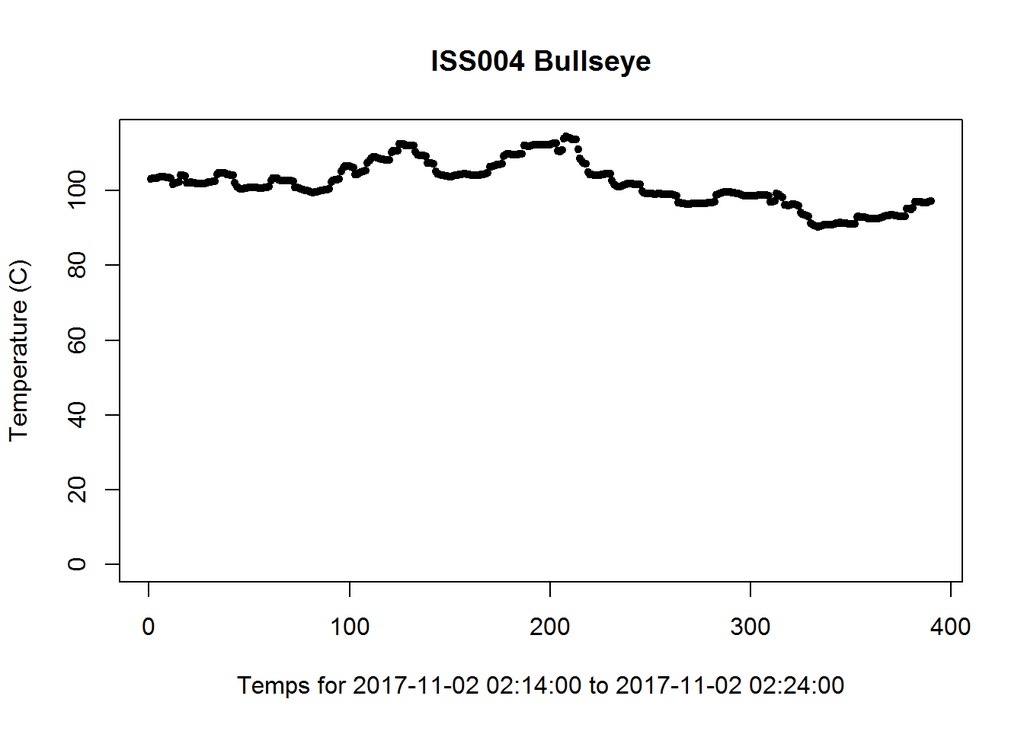

```r
TempStats(ISS004,start,duration,"ISS004 Bullseye", "scatterplot")
```

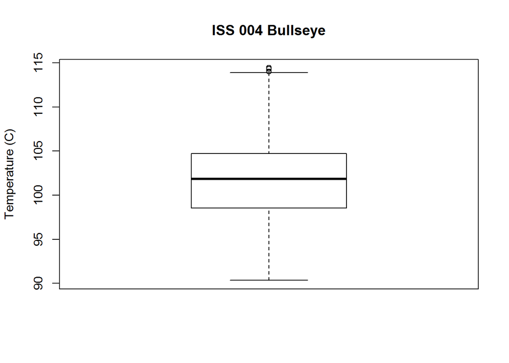

```r
boxplot(temperature~location,data=ISS4bull_duration, main="ISS 004 Bullseye", ylab="Temperature (C)")
```

```r
#temps rock at flow
#near face, left of flow
ISS<-read.csv(ISS004)
ISS$time<-ymd_hms(ISS$time)
  start<-ymd_hms("2017-11-02 T02:40:00")+minutes(1) + seconds(45) #starts ~1:45 into video _02395829.mov
  end<-ymd_hms("2017-11-02 T02:40:00") +minutes(4) + seconds(20) #ends ~4:20 into video _02395829.mov
  t_timeframe<-c(paste(start),paste(end))
ISS_duration<-subset(ISS, time>start & time<end)
ISS_summary<-sum_stats_values(ISS_duration$temperature)
ISS4_bullrock_front<-ISS_Stats(chem_time,t_timeframe,ISS_summary)

#left of near face, opp flow
  start<-ymd_hms("2017-11-02 T02:44:00")+ seconds(20) #starts ~1:45 into video _02395829.mov
  end<-ymd_hms("2017-11-02 T02:44:00") +minutes(3) + seconds(45) #ends ~4:20 into video _02395829.mov
  t_timeframe<-c(paste(start),paste(end))
ISS_duration<-subset(ISS, time>start & time<end)
ISS_summary<-sum_stats_values(ISS_duration$temperature)
ISS4_bullrock_left<-ISS_Stats(chem_time,t_timeframe,ISS_summary)


#50cm Away
  chem_time<-chem_measure(chemical_times_csv, 4,"away")
   #start<-temp_start(chemical_times_csv,4,"away")
   start<-"2017-11-02 04:06:00" #manually determined start time, using video
  t_timeframe<-TempStats_times(ISS004,start,duration)
    ISS_duration<-ISS_period(ISS004,start,duration)
  ISS_summary<-sum_stats_values(ISS_duration$temperature)
ISS4_away<-ISS_Stats(chem_time,t_timeframe,ISS_summary)

site<-"ISS 004"
location<-"away"
ISS4away_duration<-cbind(ISS_duration,site,location)

print(c(site,location))
```

```
## [1] "ISS 004" "away"
```

```r
test_chem_duration(chemical_times_csv,4,"away")
```

```
## [1] "chemistry measurement equal to greater than 15 minutes, temperatures analyzed are within chemistry measurement"
```

```
## Temperature Data from 2017-11-02 04:06:00 to 2017-11-02 04:16:00
## Summary Statistics:
## maximum = 2.01
## minimum = 1.96
## median = 1.99
## mean = 1.988
## range = 0.05
## variance = 0
## standard deviation = 0.009
## Standard Error of the Mean = 0
```

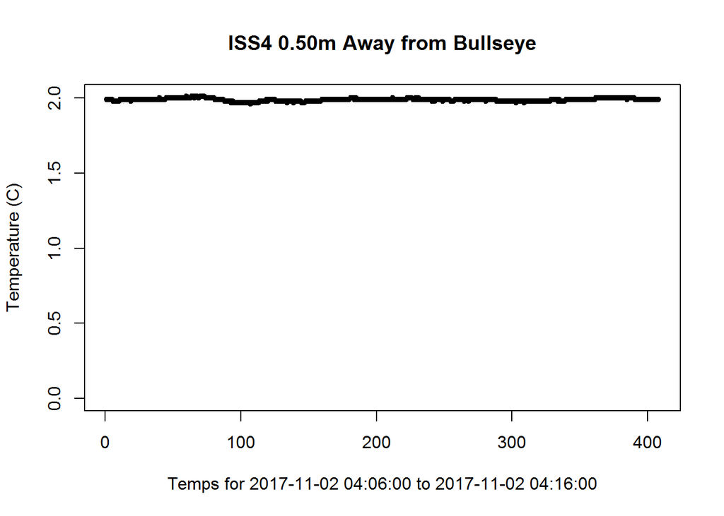

```r
TempStats(ISS004,start,duration,"ISS4 0.50m Away from Bullseye","scatterplot")
```

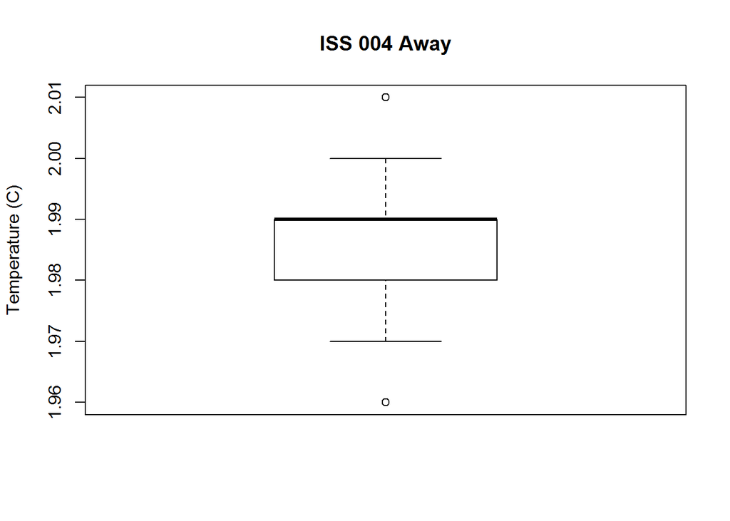

```r
boxplot(temperature~location,data=ISS4away_duration, main="ISS 004 Away", ylab="Temperature (C)")
```

```r
#Bullseye Post Excavation
  chem_time<-chem_measure(chemical_times_csv, 4,"excavated_bullseye")
    start<-temp_start(chemical_times_csv,4,"excavated_bullseye")
  t_timeframe<-TempStats_times(ISS004,start,duration)
    ISS_duration<-ISS_period(ISS004,start,duration)
  ISS_summary<-sum_stats_values(ISS_duration$temperature)
ISS4_bull_excavated<-ISS_Stats(chem_time,t_timeframe,ISS_summary)

site<-"ISS 004"
location<-"excavated bullseye"
ISS4xbul_duration<-cbind(ISS_duration,site,location)

print(c(site,location))
```

```
## [1] "ISS 004"            "excavated bullseye"
```

```r
test_chem_duration(chemical_times_csv,4,"excavated_bullseye")
```

```
## [1] "chemistry measurement equal to greater than 15 minutes, temperatures analyzed are within chemistry measurement"
```

```
## Temperature Data from 2017-11-02 06:13:00 to 2017-11-02 06:23:00
## Summary Statistics:
## maximum = 151.5
## minimum = 123.48
## median = 141.01
## mean = 140.036
## range = 28.02
## variance = 27.688
## standard deviation = 5.262
## Standard Error of the Mean = 0.267
```

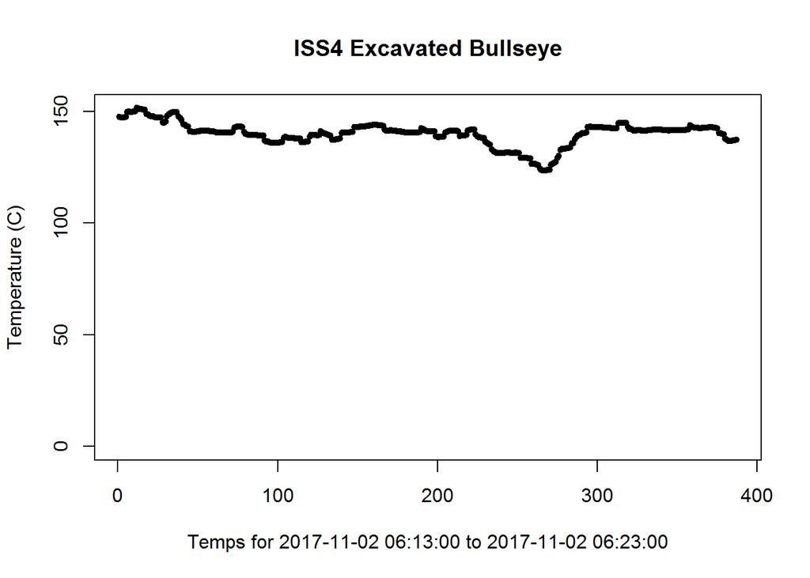

```r
TempStats(ISS004,start,duration,"ISS4 Excavated Bullseye","scatterplot")
```

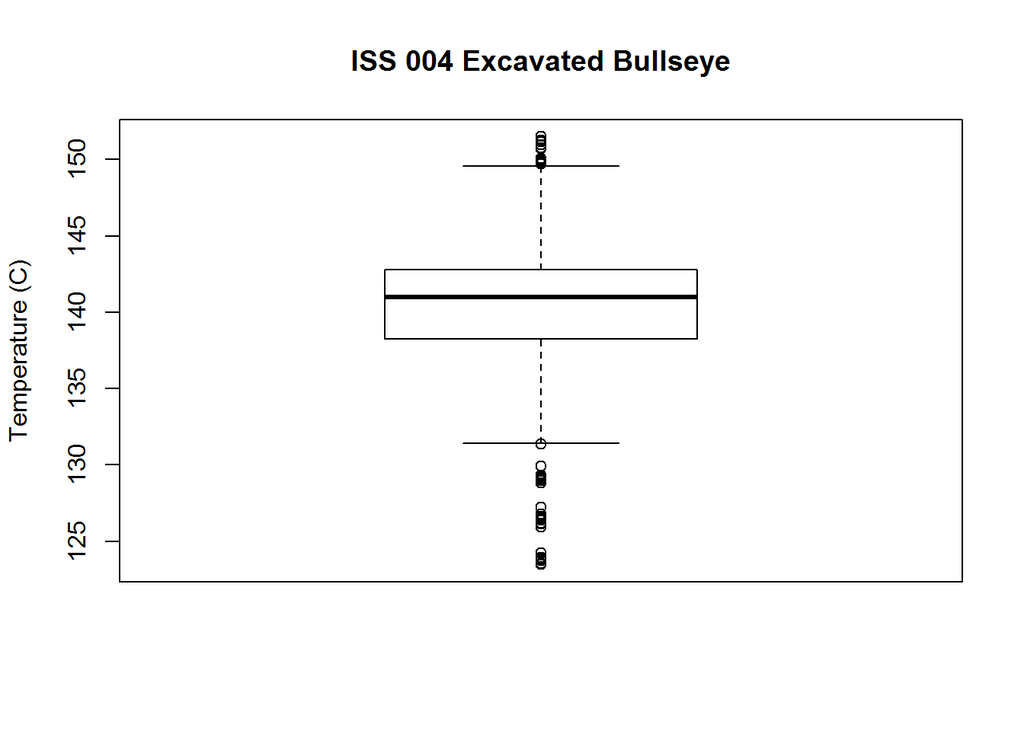

```r
boxplot(temperature~location,data=ISS4xbul_duration, main="ISS 004 Excavated Bullseye", ylab="Temperature (C)")
```

ISS 005

```r
#Bullseye #edit: there is a temp measurement before slurp and chemistry
  chem_time<-chem_measure(chemical_times_csv,5,"excavated_bullseye") #chemistry is post-excavation
#    start<-temp_start(chemical_times_csv,5,"excavated_bullseye")
    start<-"2017-11-03 T13:18:45" #manual start time from video
   duration2<-6 #duration of temp measurement <10 minutes; from video, temp measure goes to about
  t_timeframe<-TempStats_times(ISS005,start,duration2)
    ISS_duration<-ISS_period(ISS005,start,duration2)
 # t_timeframe<-TempStats_times(ISS005,start,duration2)
 #    ISS_duration<-ISS_period(ISS005,start,duration2)
  ISS_summary<-sum_stats_values(ISS_duration$temperature)
ISS5_bull_excavated<-ISS_Stats(chem_time,t_timeframe,ISS_summary)

site<-"ISS 005"
location<-"bullseye"
ISS5xbul_duration<-cbind(ISS_duration,site,location)

print(c(site,location))
```

```
## [1] "ISS 005"  "bullseye"
```

```r
#test_chem_duration(chemical_times_csv,5,"excavated_bullseye")
print("note: temperature not taken during chemistry")
```

```
## [1] "note: temperature not taken during chemistry"
```

```
## Temperature Data from 2017-11-03 13:18:45 to 2017-11-03 13:24:45
## Summary Statistics:
## maximum = 33.83
## minimum = 16.05
## median = 25.28
## mean = 26.335
## range = 17.78
## variance = 20.105
## standard deviation = 4.484
## Standard Error of the Mean = 0.292
```

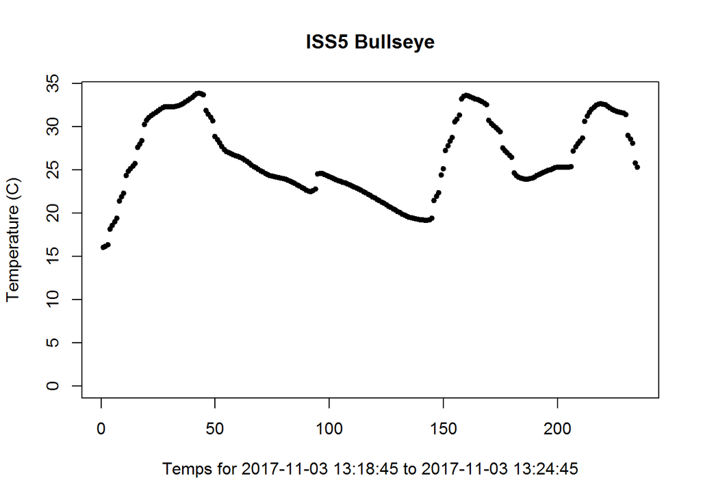

```r
TempStats(ISS005,start,duration2,"ISS5 Bullseye", "scatterplot")
```

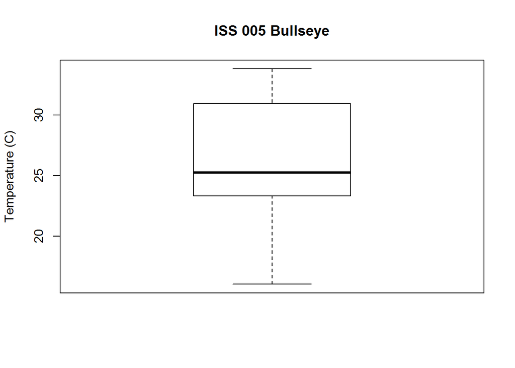

```r
boxplot(temperature~location,data=ISS5xbul_duration, main="ISS 005 Bullseye", ylab="Temperature (C)")
```

```
## Temperature Data from 2017-11-03 16:48:30 to 2017-11-03 16:52:30
## Summary Statistics:
## maximum = 17.91
## minimum = 2.46
## median = 16.51
## mean = 14.298
## range = 15.45
## variance = 19.509
## standard deviation = 4.417
## Standard Error of the Mean = 0.353
```

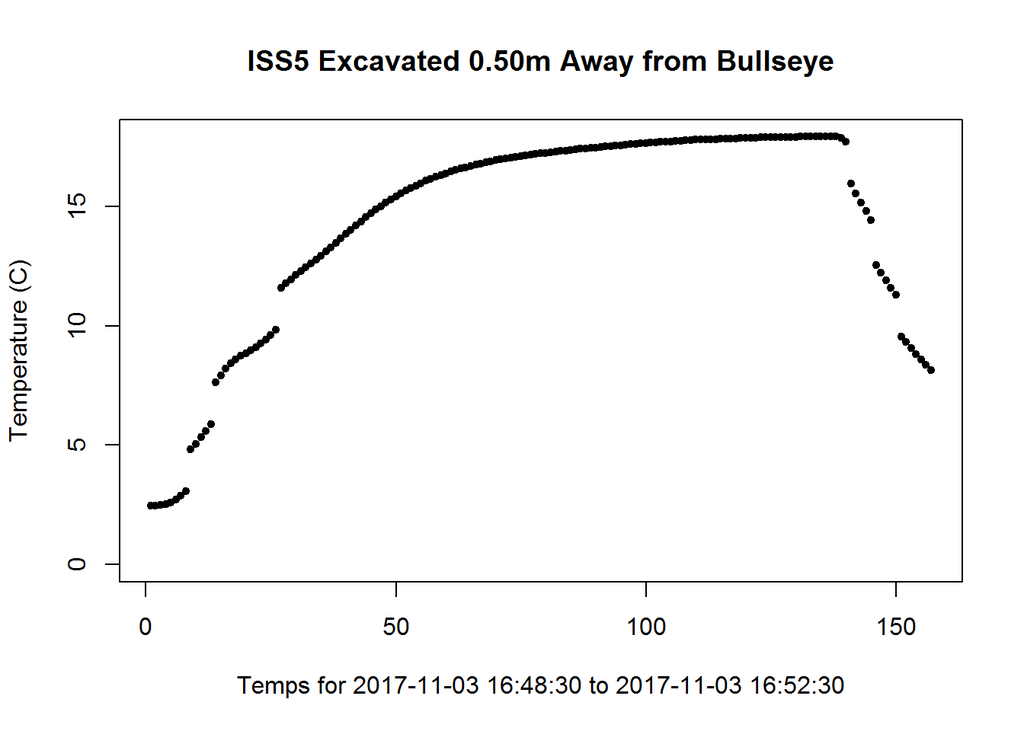

```r
#50cm Away: no chemical data given
#temp by 50cm away scar, probing temp in substrate
 start<- "2017-11-03 16:48:30"
  duration2<-4
TempStats(ISS005,start,duration2,"ISS5 Excavated 0.50m Away from Bullseye","scatterplot")
```

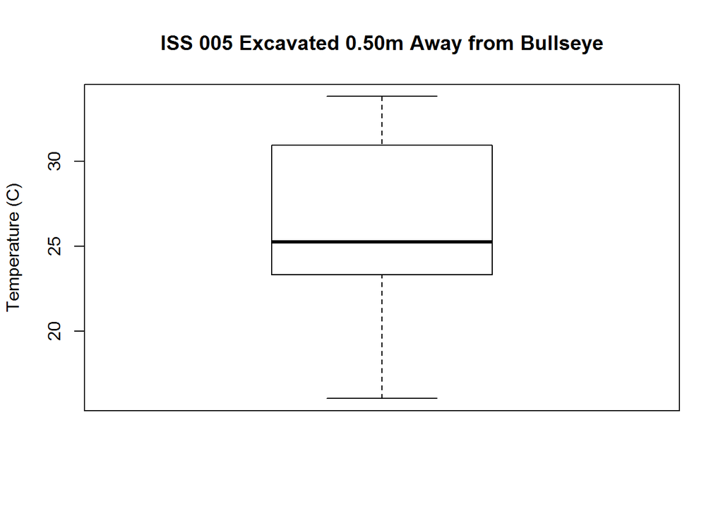

```r
  ISS5xawy_50_duration<-cbind(ISS_duration,site,location)
boxplot(temperature~location,data=ISS5xawy_50_duration, main="ISS 005 Excavated 0.50m Away from Bullseye", ylab="Temperature (C)")
```

```r
#75cm Away
#temp from moving wand around while trying (and failing to probe) into yellow
#don't have a stable measurement at away 0.75m b/c not enough time to cool, did level off ~2.5C
  chem_time<-chem_measure(chemical_times_csv,5,"excavated_away")
#   start<-temp_start(chemical_times_csv,5,"excavated_away")
  start<- "2017-11-03 16:53:00"
  duration2<-1
  t_timeframe<-TempStats_times(ISS005,start,duration2)
    ISS_duration<-ISS_period(ISS005,start,duration2)
  ISS_summary<-sum_stats_values(ISS_duration$temperature)
ISS5xawy_75<-ISS_Stats(chem_time,t_timeframe,ISS_summary)

site<-"ISS 005"
location<-"excavated away"
ISS5xawy_75_duration<-cbind(ISS_duration,site,location)

print(c(site,location))
```

```
## [1] "ISS 005"        "excavated away"
```

```r
#test_chem_duration(chemical_times_csv,5,"excavated_away")
print("note: temperature not taken during chemistry")
```

```
## [1] "note: temperature not taken during chemistry"
```

```
## Temperature Data from 2017-11-03 16:53:00 to 2017-11-03 16:54:00
## Summary Statistics:
## maximum = 3.85
## minimum = 2.48
## median = 2.785
## mean = 2.914
## range = 1.37
## variance = 0.153
## standard deviation = 0.391
## Standard Error of the Mean = 0.062
```

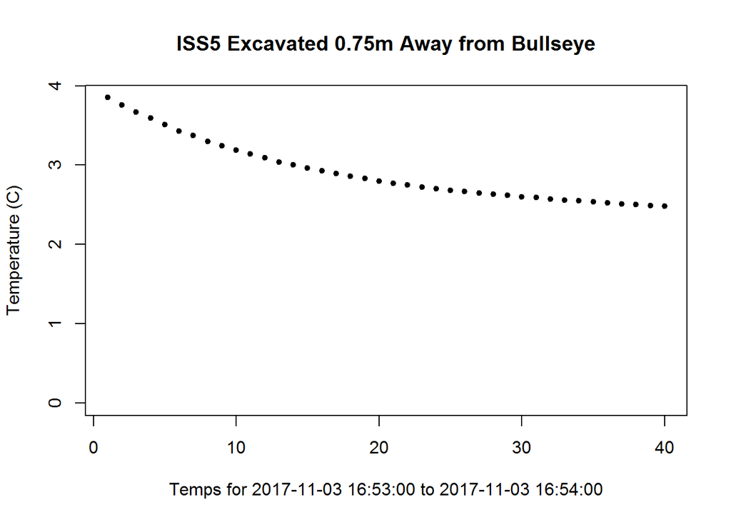

```r
TempStats(ISS005,start,duration2,"ISS5 Excavated 0.75m Away from Bullseye","scatterplot")
```

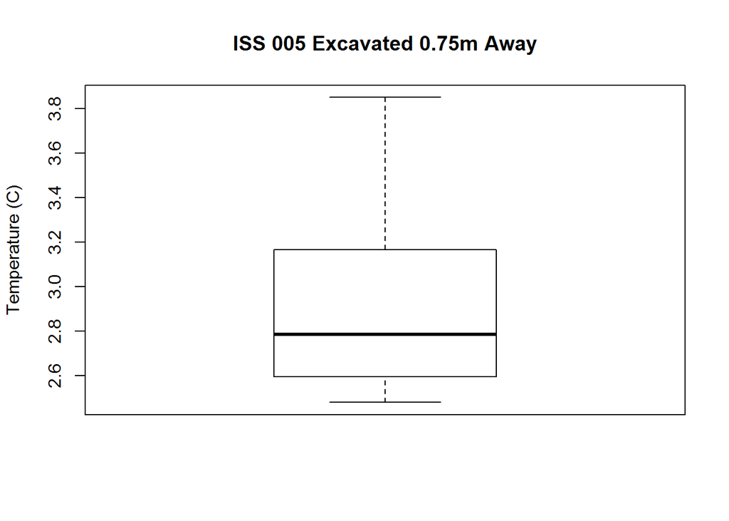

```r
boxplot(temperature~location,data=ISS5xawy_75_duration, main="ISS 005 Excavated 0.75m Away", ylab="Temperature (C)")
```

ISS 006

```r
#Bullseye
  chem_time<-chem_measure(chemical_times_csv,6,"bullseye")
    start<-temp_start(chemical_times_csv,6,"bullseye")
  t_timeframe<-TempStats_times(ISS006,start,duration)
    ISS_duration<-ISS_period(ISS006,start,duration)
  ISS_summary<-sum_stats_values(ISS_duration$temperature)
ISS6_bullseye<-ISS_Stats(chem_time,t_timeframe,ISS_summary)

site<-"ISS 006"
location<-"bullseye"
ISS6bull_duration<-cbind(ISS_duration,site,location)

print(c(site,location))
```

```
## [1] "ISS 006"  "bullseye"
```

```r
test_chem_duration(chemical_times_csv,6,"bullseye")
```

```
## [1] "chemistry measurement less than 15 minutes, temperature analysis may be outside of chemistry measurement - watch video"
```

```
## Temperature Data from 2017-11-03 18:10:00 to 2017-11-03 18:20:00
## Summary Statistics:
## maximum = 1.97
## minimum = 1.93
## median = 1.95
## mean = 1.948
## range = 0.04
## variance = 0
## standard deviation = 0.011
## Standard Error of the Mean = 0.001
```

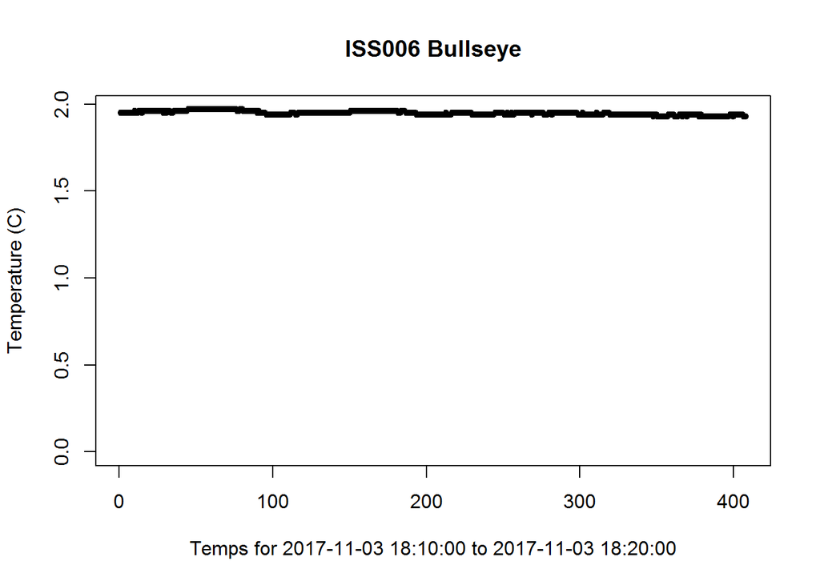

```r
TempStats(ISS006,start,duration,"ISS006 Bullseye", "scatterplot")
```

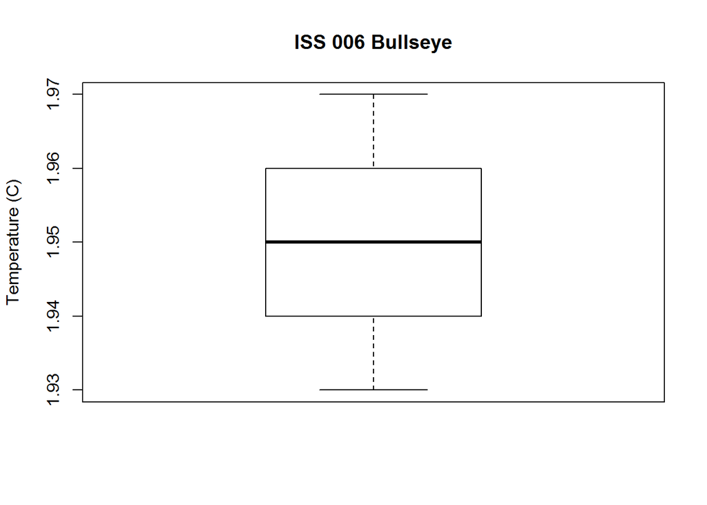

```r
boxplot(temperature~location,data=ISS6bull_duration, main="ISS 006 Bullseye", ylab="Temperature (C)")
```

```r
#Bullseye Post Excavation
  chem_time<-chem_measure(chemical_times_csv, 6,"excavated_bullseye")
    start<-temp_start(chemical_times_csv,6,"excavated_bullseye")
  t_timeframe<-TempStats_times(ISS006,start,duration)
    ISS_duration<-ISS_period(ISS006,start,duration)
  ISS_summary<-sum_stats_values(ISS_duration$temperature)
ISS6_bull_excavated<-ISS_Stats(chem_time,t_timeframe,ISS_summary)

site<-"ISS 006"
location<-"excavated bullseye"
ISS6xbul_duration<-cbind(ISS_duration,site,location)

print(c(site,location))
```

```
## [1] "ISS 006"            "excavated bullseye"
```

```r
test_chem_duration(chemical_times_csv,6,"excavated_bullseye")
```

```
## [1] "chemistry measurement equal to greater than 15 minutes, temperatures analyzed are within chemistry measurement"
```

```
## Temperature Data from 2017-11-03 22:32:00 to 2017-11-03 22:42:00
## Summary Statistics:
## maximum = 1.97
## minimum = 1.93
## median = 1.95
## mean = 1.947
## range = 0.04
## variance = 0
## standard deviation = 0.009
## Standard Error of the Mean = 0
```

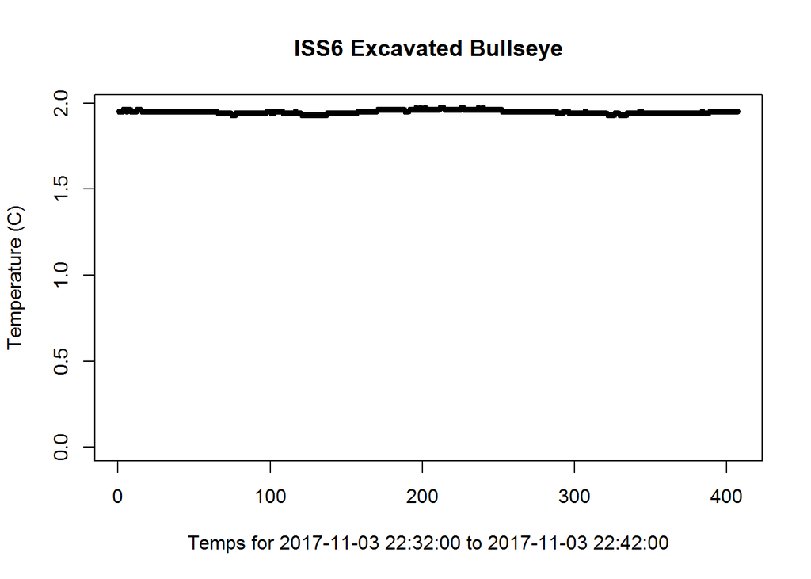

```r
TempStats(ISS006,start,duration,"ISS6 Excavated Bullseye","scatterplot")
```

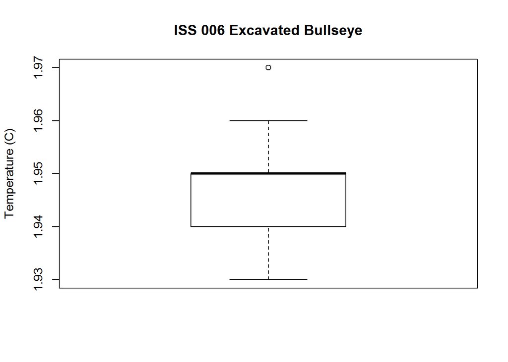

```r
boxplot(temperature~location,data=ISS6xbul_duration, main="ISS 006 Excavated Bullseye", ylab="Temperature (C)")
```

ISS 007

```r
#Bullseye ("chemical bullseye, =/= biological, exactly")
  chem_time<-chem_measure(chemical_times_csv,7,"bullseye")
    start<-temp_start(chemical_times_csv,7,"bullseye")
  t_timeframe<-TempStats_times(ISS007,start,duration)
    ISS_duration<-ISS_period(ISS007,start,duration)
  ISS_summary<-sum_stats_values(ISS_duration$temperature)
ISS7_bullseye<-ISS_Stats(chem_time,t_timeframe,ISS_summary)

site<-"ISS 007"
location<-"bullseye"
ISS7bull_duration<-cbind(ISS_duration,site,location)

print(c(site,location))
```

```
## [1] "ISS 007"  "bullseye"
```

```r
test_chem_duration(chemical_times_csv,7,"bullseye")
```

```
## [1] "chemistry measurement equal to greater than 15 minutes, temperatures analyzed are within chemistry measurement"
```

```
## Temperature Data from 2017-11-05 06:20:00 to 2017-11-05 06:30:00
## Summary Statistics:
## maximum = 1.96
## minimum = 1.92
## median = 1.94
## mean = 1.94
## range = 0.04
## variance = 0
## standard deviation = 0.008
## Standard Error of the Mean = 0
```

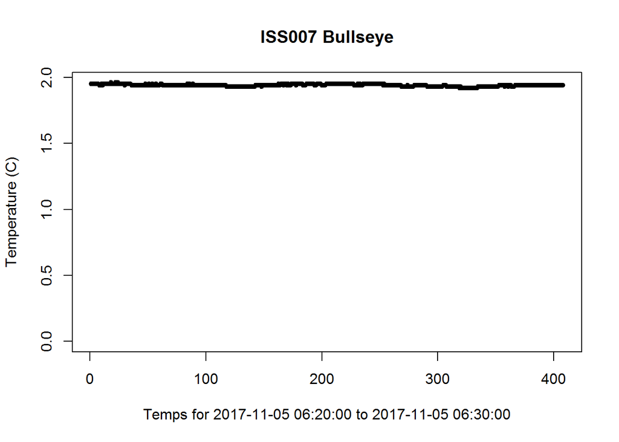

```r
TempStats(ISS007,start,duration,"ISS007 Bullseye", "scatterplot")
```

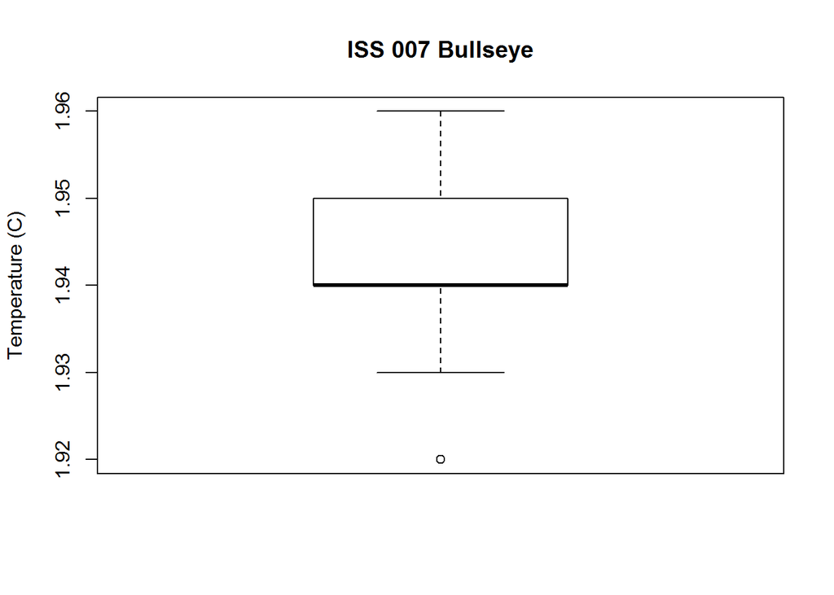

```r
boxplot(temperature~location,data=ISS7bull_duration, main="ISS 007 Bullseye", ylab="Temperature (C)")
```

```r
#Away: no chemical data

#mat temperatures (first few seconds before into sediment)
#***1st temperature, 5cm from biological bullseye***
#   whole measurement: 2017-11-05 T07:17:27 to 2017-11-05 T07:19:55
#   above flow to into sediment:
#     duration:
#
# 2nd temperature, in chemical bullseye crack
#     whole measurement: 2017-11-05 T07:22:55 to 2017-11-05 T07:27:15
#       pushed in deeper partway thru
#       above flow to into sediment:
#         duration:
#
#
# 3rd temperature, uphill of chemical bullseye, in mat nearish bio "bullseye"
#     whole measurement: 2017-11-05 T07:28:30 to 2017-11-05 T07:30:05
#     above flow to into sediment:
#         duration:
#
# ***4th temperature, downhill of chemical, in sediment nearish "away"***
#     whole measurement: 2017-11-05 T07:31:50 to 2017-11-05 T07:34:00
#     above flow to into sediment:
#         duration:
```

Table of Times and Data

```r
all<-rbind(ISS1_bullseye,ISS1_away,ISS2_bullseye,ISS2_away,ISS3_bullseye,ISS3_away,ISS4_bullseye,ISS4_bullrock_front,ISS4_bullrock_left,ISS4_away,ISS4_bull_excavated,ISS5_bull_excavated,ISS5xawy_75,ISS6_bullseye,ISS6_bull_excavated,ISS7_bullseye) #builds matrix using all station-location vectors above
columns<-c("Chem Start","Chem End","Temp Start","Temp End","Max","Min","Median","Mean","Range","Variance","St. Dev.","St. Err. Mean") #order of data in ea. vector
colnames(all)<-columns #labels matrix
all_narrow<-subset(all,select=-c(Range,Variance))
all_narrow[] <- sapply(all_narrow, gsub, pattern='T', replacement=' ')
all_narrow[] <- sapply(all_narrow, gsub, pattern='Z', replacement='')
head(all_narrow)
```

```
##               Chem Start            Chem End
## ISS1_bullseye "2017-10-31 14:43:00" "2017-10-31 15:23:00"
## ISS1_away     "2017-10-31 16:09:00" "2017-10-31 16:22:00"
## ISS2_bullseye "2017-10-31 21:16:00" "2017-10-31 21:28:00"
## ISS2_away     "2017-10-31 21:49:00" "2017-10-31 22:00:00"
## ISS3_bullseye "2017-11-01 22:22:00" "2017-11-01 22:38:00"
## ISS3_away     "2017-11-01 22:45:00" "2017-11-01 22:52:00"
##               Temp Start            Temp End              Max     Min
## ISS1_bullseye "2017-10-31 15:06:00" "2017-10-31 15:16:00" "33.99" "16.88"
## ISS1_away     "2017-10-31 16:10:00" "2017-10-31 16:17:00" "1.97"  "1.95"
## ISS2_bullseye "2017-10-31 21:13:00" "2017-10-31 21:23:00" "21.3"  "12.42"
## ISS2_away     "2017-10-31 21:40:00" "2017-10-31 21:50:00" "3.14"  "2.21"
## ISS3_bullseye "2017-11-01 22:23:00" "2017-11-01 22:33:00" "13.7"  "5.04"
## ISS3_away     "2017-11-01 22:41:00" "2017-11-01 22:47:00" "2.44"  "2.2"
##               Median   Mean     St. Dev. St. Err. Mean
## ISS1_bullseye "29.955" "28.32"  "4.911"  "0.248"
## ISS1_away     "1.96"   "1.962"  "0.005"  "0"
## ISS2_bullseye "17.87"  "17.441" "2.29"   "0.116"
## ISS2_away     "2.63"   "2.65"   "0.227"  "0.011"
## ISS3_bullseye "9.82"   "9.376"  "2.31"   "0.115"
## ISS3_away     "2.32"   "2.32"   "0.05"   "0"
```

```r
kable(all_narrow)
```

|  | Chem Start | Chem End | Temp Start | Temp End | Max | Min | Median | Mean | St. Dev. | St. Err. Mean |
| --- | --- | --- | --- | --- | --- | --- | --- | --- | --- | --- |
| ISS1_bullseye | 2017-10-31 14:43:00 | 2017-10-31 15:23:00 | 2017-10-31 15:06:00 | 2017-10-31 15:16:00 | 33.99 | 16.88 | 29.955 | 28.32 | 4.911 | 0.248 |
| ISS1_away | 2017-10-31 16:09:00 | 2017-10-31 16:22:00 | 2017-10-31 16:10:00 | 2017-10-31 16:17:00 | 1.97 | 1.95 | 1.96 | 1.962 | 0.005 | 0 |
| ISS2_bullseye | 2017-10-31 21:16:00 | 2017-10-31 21:28:00 | 2017-10-31 21:13:00 | 2017-10-31 21:23:00 | 21.3 | 12.42 | 17.87 | 17.441 | 2.29 | 0.116 |
| ISS2_away | 2017-10-31 21:49:00 | 2017-10-31 22:00:00 | 2017-10-31 21:40:00 | 2017-10-31 21:50:00 | 3.14 | 2.21 | 2.63 | 2.65 | 0.227 | 0.011 |
| ISS3_bullseye | 2017-11-01 22:22:00 | 2017-11-01 22:38:00 | 2017-11-01 22:23:00 | 2017-11-01 22:33:00 | 13.7 | 5.04 | 9.82 | 9.376 | 2.31 | 0.115 |
| ISS3_away | 2017-11-01 22:45:00 | 2017-11-01 22:52:00 | 2017-11-01 22:41:00 | 2017-11-01 22:47:00 | 2.44 | 2.2 | 2.32 | 2.32 | 0.05 | 0 |
| ISS4_bullseye | 2017-11-02 02:08:00 | 2017-11-02 02:29:00 | 2017-11-02 02:14:00 | 2017-11-02 02:24:00 | 114.44 | 90.34 | 101.845 | 101.796 | 5.91 | 0.299 |
| ISS4_bullrock_front | 2017-11-02 02:08:00 | 2017-11-02 02:29:00 | 2017-11-02 02:41:45 | 2017-11-02 02:44:20 | 11.12 | 6.09 | 7.415 | 7.5 | 1.193 | 0.116 |
| ISS4_bullrock_left | 2017-11-02 02:08:00 | 2017-11-02 02:29:00 | 2017-11-02 02:44:20 | 2017-11-02 02:47:45 | 7.37 | 3.26 | 4.89 | 4.927 | 0.976 | 0.083 |
| ISS4_away | 2017-11-02 04:08:00 | 2017-11-02 04:26:00 | 2017-11-02 04:06:00 | 2017-11-02 04:16:00 | 2.01 | 1.96 | 1.99 | 1.988 | 0.009 | 0 |
| ISS4_bull_excavated | 2017-11-02 05:40:00 | 2017-11-02 06:28:00 | 2017-11-02 06:13:00 | 2017-11-02 06:23:00 | 151.5 | 123.48 | 141.01 | 140.036 | 5.262 | 0.267 |
| ISS5_bull_excavated | 2017-11-03 14:32:00 | 2017-11-03 14:56:00 | 2017-11-03 13:18:45 | 2017-11-03 13:24:45 | 33.83 | 16.05 | 25.28 | 26.335 | 4.484 | 0.292 |
| ISS5xawy_75 | 2017-11-03 16:28:00 | 2017-11-03 17:00:00 | 2017-11-03 16:53:00 | 2017-11-03 16:54:00 | 3.85 | 2.48 | 2.785 | 2.914 | 0.391 | 0.062 |
| ISS6_bullseye | 2017-11-03 18:22:00 | 2017-11-03 18:25:00 | 2017-11-03 18:10:00 | 2017-11-03 18:20:00 | 1.97 | 1.93 | 1.95 | 1.948 | 0.011 | 0.001 |
| ISS6_bull_excavated | 2017-11-03 22:16:00 | 2017-11-03 22:47:00 | 2017-11-03 22:32:00 | 2017-11-03 22:42:00 | 1.97 | 1.93 | 1.95 | 1.947 | 0.009 | 0 |
| ISS7_bullseye | 2017-11-05 06:20:00 | 2017-11-05 06:35:00 | 2017-11-05 06:20:00 | 2017-11-05 06:30:00 | 1.96 | 1.92 | 1.94 | 1.94 | 0.008 | 0 |

```r
print("Temperature data times from near last 10min of chemistry data. All times are UTC, and temperatures in degrees C.")
```

```
## [1] "Temperature data times from near last 10min of chemistry data. All times are UTC, and temperatures in degrees C."
```

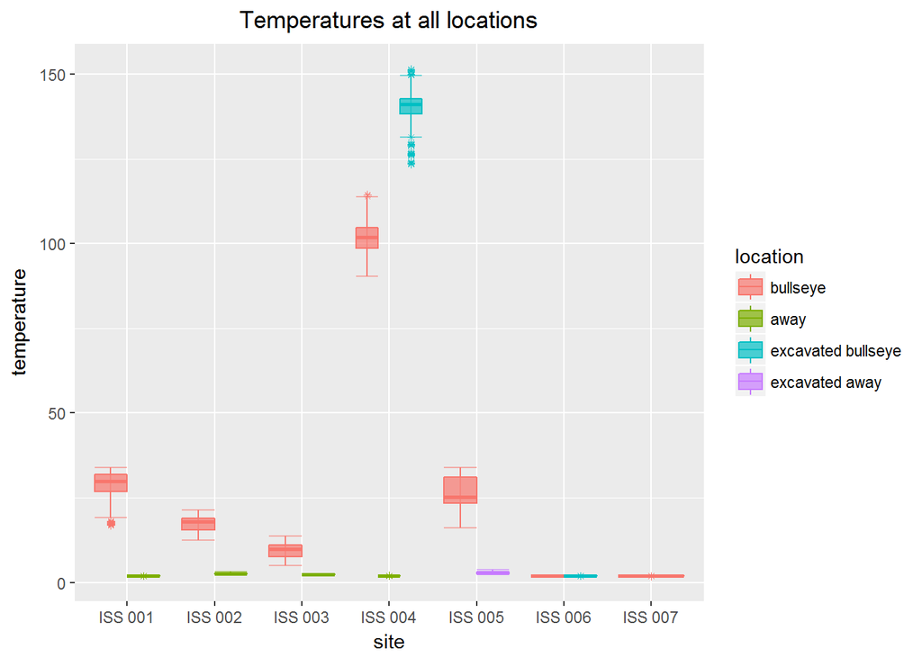

```r
boxplot_all<-rbind(ISS1bull_duration,ISS1away_duration,ISS2bull_duration,ISS2away_duration,ISS3bull_duration,ISS3away_duration,ISS4bull_duration,
                   ISS4away_duration,ISS4xbul_duration,ISS5xbul_duration,ISS5xawy_50_duration,ISS5xawy_75_duration,ISS6bull_duration,ISS6xbul_duration,ISS7bull_duration) #put all relevant temperature data together (for boxplot)

boxplot_away<-rbind(ISS1away_duration,ISS2away_duration,ISS3away_duration,ISS4away_duration,ISS5xawy_75_duration) #all away data together
boxplot_at<-rbind(ISS1bull_duration,ISS2bull_duration,ISS3bull_duration,ISS4bull_duration,ISS4xbul_duration, #all bullseye data together
                  ISS5xbul_duration,ISS6bull_duration,ISS6xbul_duration,ISS7bull_duration)

ggplot(boxplot_all, aes(x=site, y=temperature, color=location, fill=location, alpha=0.25)) + #boxplot all temp data, color based on location
  stat_boxplot(geom ='errorbar', show.legend = FALSE) +
  geom_boxplot(outlier.shape = 8,outlier.size = 1, alpha = 0.7) +
  labs(title="Temperatures at all locations") +
  theme(plot.title = element_text(hjust = 0.5))
```

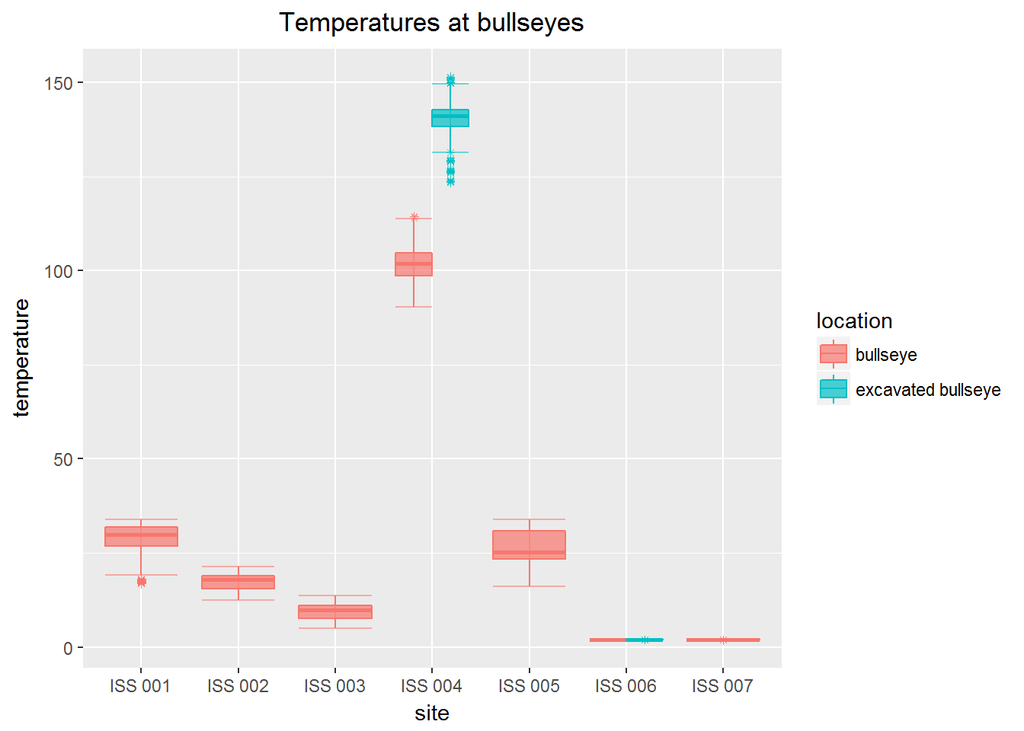

```r
  #geom_point(alpha=1, pch=20)
ggplot(boxplot_at, aes(x=site, y=temperature, color=location, fill=location, alpha=0.25)) + #boxplot bullseye temp datas, colors ~to as in above
  stat_boxplot(geom ='errorbar', show.legend = FALSE) +
  geom_boxplot(outlier.shape = 8,outlier.size = 1, alpha = 0.7)+
  labs(title="Temperatures at bullseyes")+
  theme(plot.title = element_text(hjust = 0.5))
```

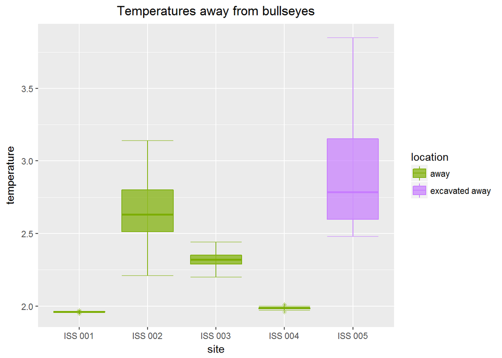

```r
ggplot(boxplot_away, aes(x=site, y=temperature, color=location, fill=location, alpha=0.25)) + #boxplot bullseye temp datas, colors ~as in above
  stat_boxplot(geom ='errorbar', show.legend = FALSE) +
  geom_boxplot(outlier.shape = 8,outlier.size = 1, alpha = 0.7) +
 scale_fill_manual(breaks=c("away","excavated away"), values=c("#7CAE00","#C77CFF")) + #colors from library(scales), show_col(hue_pal()(4)) to display colors used in first ggplot
  scale_color_manual(breaks=c("away","excavated away"), values=c("#7CAE00","#C77CFF")) +
  labs(title="Temperatures away from bullseyes")+
  theme(plot.title = element_text(hjust = 0.5))
```